# Part II - Loan Data from Prosper

## by Isaac Ninson

## Investigation Overview

> I would like to investigate the impact of Prosper Rating on some of the other variable since the Rating has been found to be critical in determining Loan Amount a Borrower can secure as well as the APR a Borrower can get.

## Dataset Overview

> The dataset is made up of 61482 rows with 14 columns. This is the same data I used in Part 1 of this project. Data is indexed by the unique member key of each borrower. The 14 columns is made up of 9 categorical data and 5 numerical data. Data has already been cleaned.

## Distribution of Prosper Rating

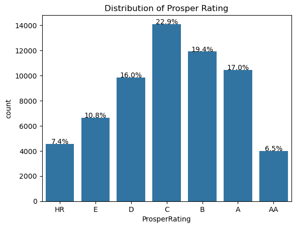

## Impact of Rating on APR Base on Borrower's Employment Status

> Employed who are rated between AA, A or B had lower APR compared to the self-employed but employed borrowers rated below B had higher APR compared to the Self-employed. The retired genrally had the lowest APR for ratings AA,A or B but the highest APR for the low ratings.

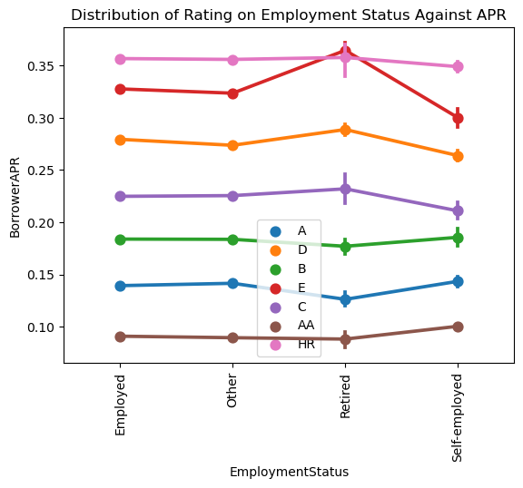

## Impact of Rating on Loan Amount and Loan Term

> As rating increases, a borrower has the capacity to secure high loan amount with an increaseed loan term. At high ratings AA, A or B, Borrowers had the same average amount for Long Term Loans meaning at these ratings, Borrowers have access to almost same range of loan amounts.

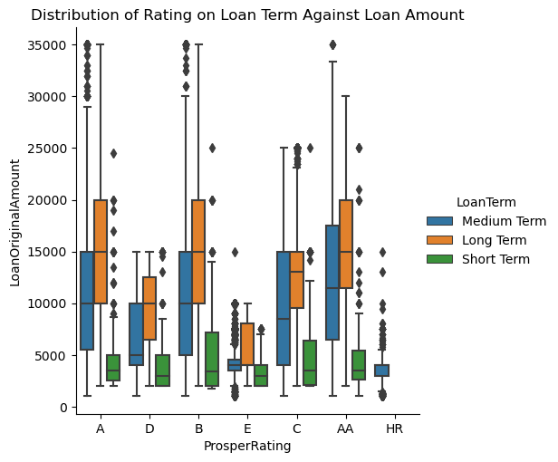

## Impact of Homeowner on Rating and Loan Amount

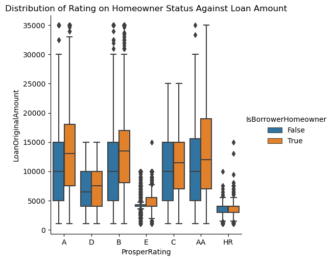